# Chapter 5

## Q2

Below, I give two figures to visualize the PCA. The scree plot shows how much each principal component accounts for the total variance of the variables. We see that the first PC accounts for virtually all of the variance in the data. This can be confirmed from the biplot, in which only one arrow is visible, as the others would have length zero. This PC corresponds to the varible **GNI**, which is of two or three orders of magnitudes larger than the other variables. Therefore, the analysis using the non-standardized variables makes little sense here.

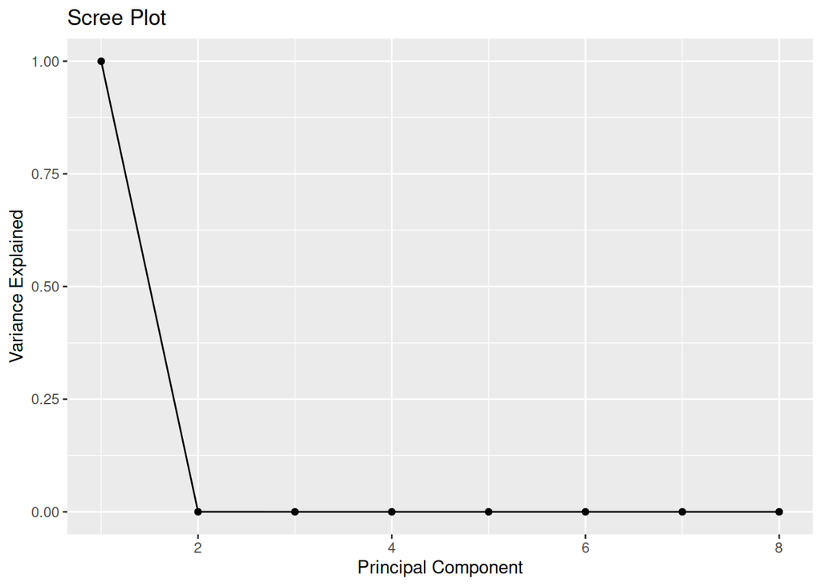

```r
pca_human <- prcomp(human %>% dplyr::select(-Country))
var_explained <- pca_human$sdev^2 / sum(pca_human$sdev^2)
qplot(x = 1:8, y = var_explained) +
  geom_line() +
  xlab("Principal Component") +
  ylab("Variance Explained") +
  ggtitle("Scree Plot") +
  ylim(0, 1)
```

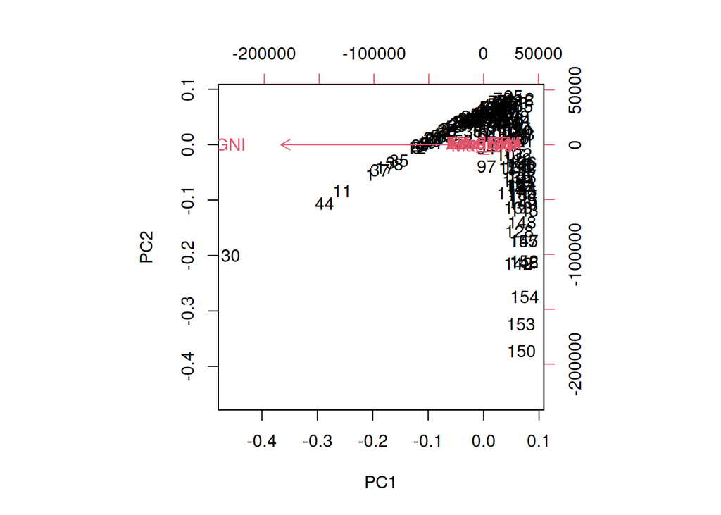

```r
biplot(pca_human, choices = 1:2)
```

## Q3

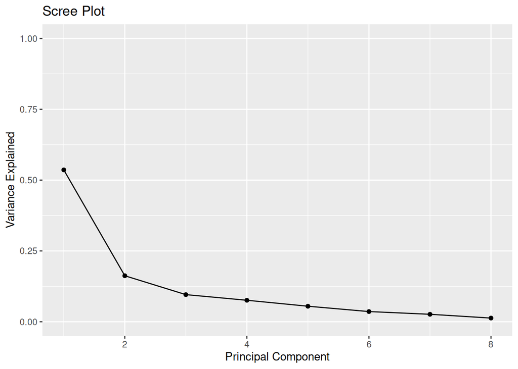

```r
pca_human <- human %>%
  # Select only numeric cols
  dplyr::select(-Country) %>%
  # S'dize data
  mutate_all( ~ (.x-mean(.x))/sd(.x)) %>%
  prcomp()
# calculate the variance explained per variable
var_explained <- pca_human$sdev^2 / sum(pca_human$sdev^2)
# them agains the number of PCs (8)
qplot(1:8, var_explained) +
  geom_line() +
  xlab("Principal Component") +
  ylab("Variance Explained") +
  ggtitle("Scree Plot") +
  ylim(0, 1)
```

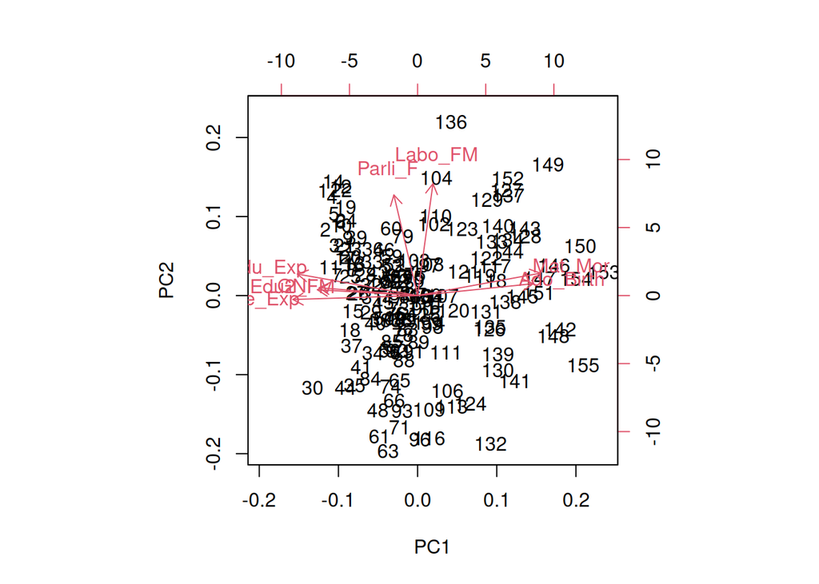

```r
pca_human %>% biplot(choices = 1:2)
```

## Q5

```r
tea <- read.csv("https://raw.githubusercontent.com/KimmoVehkalahti/Helsinki-Open-Data-Science/master/datasets/tea.csv", stringsAsFactors = TRUE)
cls <- tea %>% apply(2, class)
# select 10 random columns
tea_rd <- tea %>% dplyr::select(sample(1:ncol(tea), 10, replace = FALSE))
tea_rd %>% str
```

```
## 'data.frame':    300 obs. of  10 variables:
##  $ feminine: Factor w/ 2 levels "feminine","Not.feminine": 2 2 2 2 2 2 2 1 2 2 ...
##  $ sugar   : Factor w/ 2 levels "No.sugar","sugar": 2 1 1 2 1 1 1 1 1 1 ...
##  $ How     : Factor w/ 4 levels "alone","lemon",..: 1 3 1 1 1 1 1 3 3 1 ...
##  $ evening : Factor w/ 2 levels "evening","Not.evening": 2 2 1 2 1 2 2 1 2 1 ...
##  $ friends : Factor w/ 2 levels "friends","Not.friends": 2 2 1 2 2 2 1 2 2 2 ...
##  $ price   : Factor w/ 6 levels "p_branded","p_cheap",..: 4 6 6 6 6 3 6 6 5 5 ...
##  $ Sport   : Factor w/ 2 levels "Not.sportsman",..: 2 2 2 1 2 2 2 2 2 1 ...
##  $ resto   : Factor w/ 2 levels "Not.resto","resto": 1 1 2 1 1 1 1 1 1 1 ...
##  $ dinner  : Factor w/ 2 levels "dinner","Not.dinner": 2 2 1 1 2 1 2 2 2 2 ...
##  $ sex     : Factor w/ 2 levels "F","M": 2 1 1 2 2 2 2 1 2 2 ...
```

In this data set, I pick randomly ten out of 36 variables for the multiple correspondence analysis. The data are categorical and shown in figure below. The unique values per variable vary from two to six. Some the variables exhibit little variation, e.g. **dinner**, while variable **price** varies considerably more.

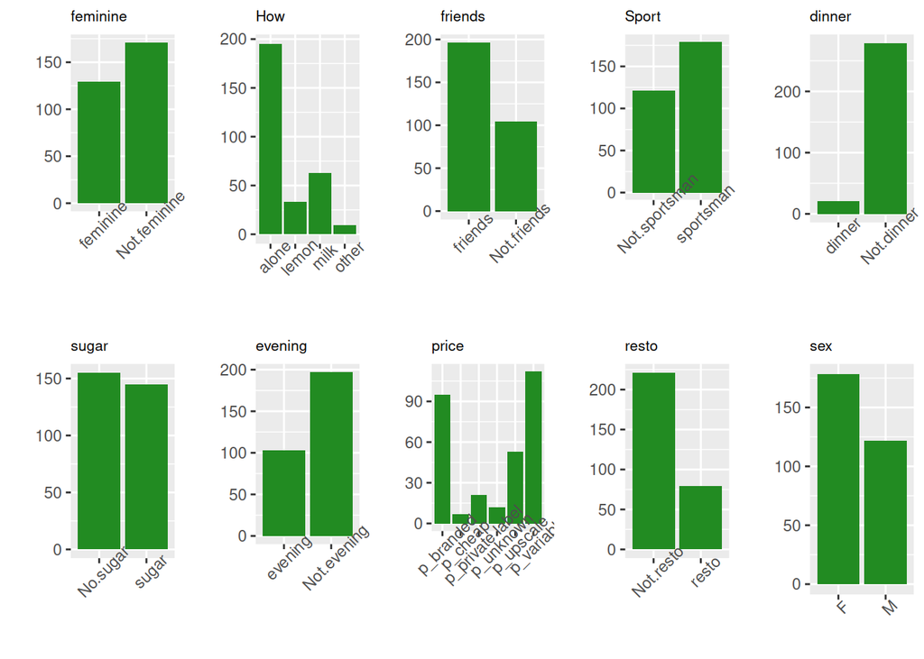

```r
# calculate the number of cases per factor for each variable
get_counts <- apply(tea_rd, 2, table)
plot_list <- list()
for(jj in 1:10){
  # run a loop over the variables s.t. for each var a bar plot is created
  plot_list[[jj]] <- tibble(count = get_counts[[jj]], char = names(get_counts[[jj]])) %>%
    ggplot(aes(x=char, y = count)) +
    geom_bar(stat='identity', fill = "forest green") +
    xlab("") +
    ylab("") +
    ggtitle(names(get_counts)[jj]) +
    theme(axis.text.x = element_text(angle = 45),
          plot.title = element_text(size = 8))

}
# plot variables in a 2-by-5 matrix
gridExtra::marrangeGrob(plot_list, nrow = 2, ncol = 5, top = FALSE)
```

Below I conduct MCA and explore the results .

```r
mca <- FactoMineR::MCA(as.matrix(tea_rd), graph = FALSE)
summary(mca)
```

```
##
## Call:
## FactoMineR::MCA(X = as.matrix(tea_rd), graph = FALSE)
##
##
## Eigenvalues
##                        Dim.1   Dim.2   Dim.3   Dim.4   Dim.5   Dim.6   Dim.7
## Variance               0.169   0.152   0.128   0.121   0.117   0.104   0.103
## % of var.             10.543   9.511   8.029   7.586   7.298   6.503   6.445
## Cumulative % of var.  10.543  20.054  28.083  35.669  42.967  49.470  55.916
##                        Dim.8   Dim.9  Dim.10  Dim.11  Dim.12  Dim.13  Dim.14
## Variance               0.099   0.094   0.091   0.085   0.079   0.074   0.067
## % of var.              6.183   5.853   5.687   5.295   4.939   4.647   4.182
## Cumulative % of var.  62.099  67.952  73.639  78.934  83.872  88.519  92.701
##                       Dim.15  Dim.16
## Variance               0.063   0.054
## % of var.              3.948   3.351
## Cumulative % of var.  96.649 100.000
##
## Individuals (the 10 first)
##                 Dim.1    ctr   cos2    Dim.2    ctr   cos2    Dim.3    ctr
## 1            |  0.813  1.305  0.211 | -0.069  0.010  0.002 |  0.346  0.311
## 2            |  0.108  0.023  0.010 | -0.256  0.144  0.058 | -0.161  0.067
## 3            |  0.191  0.072  0.015 |  0.590  0.762  0.146 | -0.775  1.558
## 4            |  0.625  0.772  0.170 | -0.350  0.268  0.053 | -0.276  0.197
## 5            |  0.412  0.335  0.165 |  0.000  0.000  0.000 | -0.364  0.343
## 6            |  0.820  1.329  0.200 | -0.731  1.170  0.158 | -0.343  0.305
## 7            |  0.248  0.122  0.082 |  0.037  0.003  0.002 | -0.402  0.419
## 8            | -0.175  0.060  0.023 | -0.057  0.007  0.002 | -0.049  0.006
## 9            |  0.657  0.853  0.286 | -0.432  0.409  0.124 | -0.174  0.078
## 10           |  0.363  0.260  0.094 | -0.235  0.121  0.039 | -0.257  0.171
##                cos2
## 1             0.038 |
## 2             0.023 |
## 3             0.252 |
## 4             0.033 |
## 5             0.129 |
## 6             0.035 |
## 7             0.214 |
## 8             0.002 |
```

[output cut: 24 more lines]

```
## evening        9.388 |   0.112   0.332   0.007   1.394 |
## Not.evening   -9.388 |  -0.058   0.174   0.007  -1.394 |
##
## Categorical variables (eta2)
##                Dim.1 Dim.2 Dim.3
## feminine     | 0.439 0.033 0.013 |
## sugar        | 0.103 0.014 0.289 |
## How          | 0.065 0.102 0.441 |
## evening      | 0.007 0.295 0.007 |
## friends      | 0.055 0.375 0.000 |
## price        | 0.122 0.229 0.344 |
## Sport        | 0.201 0.002 0.087 |
## resto        | 0.007 0.458 0.004 |
## dinner       | 0.114 0.009 0.092 |
## sex          | 0.573 0.005 0.007 |
```

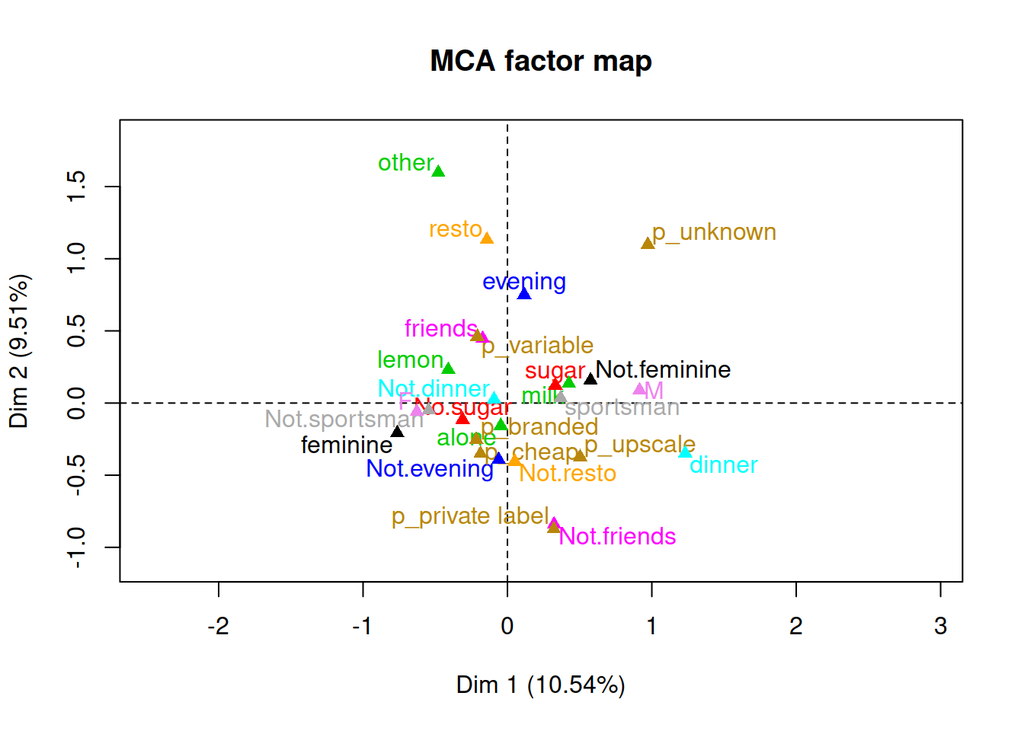

```r
plot(mca, invisible="ind", graph.type = "classic", habillage = "quali")
```